# Practical Machine Learning Final Project

Anonymous

February 13, 2016

# Background

This is the final project for the Cousera “Practical Machine Learning” class. The relevant background for the data is as follows:

> Six young health participants were asked to perform one set of 10 repetitions of the Unilateral Dumbbell Biceps Curl in five different fashions: exactly according to the specification (Class A), throwing the elbows to the front (Class B), lifting the dumbbell only halfway (Class C), lowering the dumbbell only halfway (Class D) and throwing the hips to the front (Class E).

> Class A corresponds to the specified execution of the exercise, while the other 4 classes correspond to common mistakes. Participants were supervised by an experienced weight lifter to make sure the execution complied to the manner they were supposed to simulate. The exercises were performed by six male participants aged between 20-28 years, with little weight lifting experience. We made sure that all participants could easily simulate the mistakes in a safe and controlled manner by using a relatively light dumbbell (1.25kg).

## Acknowledgement

The data for this project come from this source: http://groupware.les.inf.puc-rio.br/har. We appreciate the generosity in allowing their data to be used for this kind of assignment.

# My Model

In this project, I created a model to predict the class of subjects in a **test** dataset. I built the model using a **training** dataset.

## Preliminaries

The library calls:

```r
# Library calls
library(magrittr)
library(dplyr)
library(caret)
library(rattle)
```

## Read in the data

I read in the data in mid-February, 2016 using the following commands:

```r
train_url <- "https://d396qusza40orc.cloudfront.net/predmachlearn/pml-training.csv"
train_data <- read.csv(train_url)

train_data_orig <- train_data # Keep a copy so we dont need to reload

train_data <- train_data_orig # Run if necessary

test_url <- "https://d396qusza40orc.cloudfront.net/predmachlearn/pml-testing.csv"
test_data <- read.csv(test_url)
```

## Data Munging

```r
# Step 2: Data Munging
str(train_data)
```

```
## 'data.frame':    19622 obs. of  160 variables:
##  $ X                       : int  1 2 3 4 5 6 7 8 9 10 ...
##  $ user_name               : Factor w/ 6 levels "adelmo","carlitos",..: 2 2 2 2 2 2 2 2 2 2 ...
##  $ raw_timestamp_part_1    : int  1323084231 1323084231 1323084231 1323084232 1323084232 1323084232 1323084232 1323084232 1323084232 1323084232 ...
##  $ raw_timestamp_part_2    : int  788290 808298 820366 120339 196328 304277 368296 440390 484323 484434 ...
##  $ cvtd_timestamp          : Factor w/ 20 levels "02/12/2011 13:32",..: 9 9 9 9 9 9 9 9 9 9 ...
##  $ new_window              : Factor w/ 2 levels "no","yes": 1 1 1 1 1 1 1 1 1 1 ...
##  $ num_window              : int  11 11 11 12 12 12 12 12 12 12 ...
##  $ roll_belt               : num  1.41 1.41 1.42 1.48 1.48 1.45 1.42 1.42 1.43 1.45 ...
##  $ pitch_belt              : num  8.07 8.07 8.07 8.05 8.07 8.06 8.09 8.13 8.16 8.17 ...
##  $ yaw_belt                : num  -94.4 -94.4 -94.4 -94.4 -94.4 -94.4 -94.4 -94.4 -94.4 -94.4 ...
##  $ total_accel_belt        : int  3 3 3 3 3 3 3 3 3 3 ...
##  $ kurtosis_roll_belt      : Factor w/ 397 levels "","-0.016850",..: 1 1 1 1 1 1 1 1 1 1 ...
##  $ kurtosis_picth_belt     : Factor w/ 317 levels "","-0.021887",..: 1 1 1 1 1 1 1 1 1 1 ...
##  $ kurtosis_yaw_belt       : Factor w/ 2 levels "","#DIV/0!": 1 1 1 1 1 1 1 1 1 1 ...
```

[output cut: 86 more lines]

Clearly many of the variables are not well populated. Lets figure out which ones.

```r
missing <- lapply(X = train_data, FUN = function(var) {
  length(which(is.na(var))) / nrow(train_data)
}) %>%
  unlist()
missing
```

```
##                        X                user_name     raw_timestamp_part_1
##                0.0000000                0.0000000                0.0000000
##     raw_timestamp_part_2           cvtd_timestamp               new_window
##                0.0000000                0.0000000                0.0000000
##               num_window                roll_belt               pitch_belt
##                0.0000000                0.0000000                0.0000000
##                 yaw_belt         total_accel_belt       kurtosis_roll_belt
##                0.0000000                0.0000000                0.0000000
##      kurtosis_picth_belt        kurtosis_yaw_belt       skewness_roll_belt
##                0.0000000                0.0000000                0.0000000
##     skewness_roll_belt.1        skewness_yaw_belt            max_roll_belt
##                0.0000000                0.0000000                0.9793089
##           max_picth_belt             max_yaw_belt            min_roll_belt
##                0.9793089                0.0000000                0.9793089
##           min_pitch_belt             min_yaw_belt      amplitude_roll_belt
##                0.9793089                0.0000000                0.9793089
##     amplitude_pitch_belt       amplitude_yaw_belt     var_total_accel_belt
##                0.9793089                0.0000000                0.9793089
##            avg_roll_belt         stddev_roll_belt            var_roll_belt
##                0.9793089                0.9793089                0.9793089
##           avg_pitch_belt        stddev_pitch_belt           var_pitch_belt
##                0.9793089                0.9793089                0.9793089
##             avg_yaw_belt          stddev_yaw_belt             var_yaw_belt
##                0.9793089                0.9793089                0.9793089
##             gyros_belt_x             gyros_belt_y             gyros_belt_z
##                0.0000000                0.0000000                0.0000000
##             accel_belt_x             accel_belt_y             accel_belt_z
##                0.0000000                0.0000000                0.0000000
##            magnet_belt_x            magnet_belt_y            magnet_belt_z
##                0.0000000                0.0000000                0.0000000
##                 roll_arm                pitch_arm                  yaw_arm
##                0.0000000                0.0000000                0.0000000
##          total_accel_arm            var_accel_arm             avg_roll_arm
##                0.0000000                0.9793089                0.9793089
##          stddev_roll_arm             var_roll_arm            avg_pitch_arm
##                0.9793089                0.9793089                0.9793089
##         stddev_pitch_arm            var_pitch_arm              avg_yaw_arm
##                0.9793089                0.9793089                0.9793089
##           stddev_yaw_arm              var_yaw_arm              gyros_arm_x
##                0.9793089                0.9793089                0.0000000
```

[output cut: 53 more lines]

```
##                0.0000000                0.0000000                0.9793089
##         avg_roll_forearm      stddev_roll_forearm         var_roll_forearm
##                0.9793089                0.9793089                0.9793089
##        avg_pitch_forearm     stddev_pitch_forearm        var_pitch_forearm
##                0.9793089                0.9793089                0.9793089
##          avg_yaw_forearm       stddev_yaw_forearm          var_yaw_forearm
##                0.9793089                0.9793089                0.9793089
##          gyros_forearm_x          gyros_forearm_y          gyros_forearm_z
##                0.0000000                0.0000000                0.0000000
##          accel_forearm_x          accel_forearm_y          accel_forearm_z
##                0.0000000                0.0000000                0.0000000
##         magnet_forearm_x         magnet_forearm_y         magnet_forearm_z
##                0.0000000                0.0000000                0.0000000
##                   classe
##                0.0000000
```

I decided to drop the variables that are missing for ~97.9% of our records.

```r
train_data <- train_data[,-which(missing > 0)]
```

Now lets look at a summary of the variables we have left:

```r
str(train_data)
```

```
## 'data.frame':    19622 obs. of  93 variables:
##  $ X                      : int  1 2 3 4 5 6 7 8 9 10 ...
##  $ user_name              : Factor w/ 6 levels "adelmo","carlitos",..: 2 2 2 2 2 2 2 2 2 2 ...
##  $ raw_timestamp_part_1   : int  1323084231 1323084231 1323084231 1323084232 1323084232 1323084232 1323084232 1323084232 1323084232 1323084232 ...
##  $ raw_timestamp_part_2   : int  788290 808298 820366 120339 196328 304277 368296 440390 484323 484434 ...
##  $ cvtd_timestamp         : Factor w/ 20 levels "02/12/2011 13:32",..: 9 9 9 9 9 9 9 9 9 9 ...
##  $ new_window             : Factor w/ 2 levels "no","yes": 1 1 1 1 1 1 1 1 1 1 ...
##  $ num_window             : int  11 11 11 12 12 12 12 12 12 12 ...
##  $ roll_belt              : num  1.41 1.41 1.42 1.48 1.48 1.45 1.42 1.42 1.43 1.45 ...
##  $ pitch_belt             : num  8.07 8.07 8.07 8.05 8.07 8.06 8.09 8.13 8.16 8.17 ...
##  $ yaw_belt               : num  -94.4 -94.4 -94.4 -94.4 -94.4 -94.4 -94.4 -94.4 -94.4 -94.4 ...
##  $ total_accel_belt       : int  3 3 3 3 3 3 3 3 3 3 ...
##  $ kurtosis_roll_belt     : Factor w/ 397 levels "","-0.016850",..: 1 1 1 1 1 1 1 1 1 1 ...
##  $ kurtosis_picth_belt    : Factor w/ 317 levels "","-0.021887",..: 1 1 1 1 1 1 1 1 1 1 ...
##  $ kurtosis_yaw_belt      : Factor w/ 2 levels "","#DIV/0!": 1 1 1 1 1 1 1 1 1 1 ...
```

[output cut: 79 more lines]

The data are a mix of numeric(integer) and factor variables. Let’s look at the factor variables

```r
which_factors <- which(lapply(X = train_data, FUN = class) == "factor")
lapply(X = train_data[,which_factors], summary)
```

```
## $user_name
##   adelmo carlitos  charles   eurico   jeremy    pedro
##     3892     3112     3536     3070     3402     2610
##
## $cvtd_timestamp
## 02/12/2011 13:32 02/12/2011 13:33 02/12/2011 13:34 02/12/2011 13:35
##              177             1321             1375             1019
## 02/12/2011 14:56 02/12/2011 14:57 02/12/2011 14:58 02/12/2011 14:59
##              235             1380             1364              557
## 05/12/2011 11:23 05/12/2011 11:24 05/12/2011 11:25 05/12/2011 14:22
##              190             1497             1425              267
## 05/12/2011 14:23 05/12/2011 14:24 28/11/2011 14:13 28/11/2011 14:14
##             1370              973              833             1498
## 28/11/2011 14:15 30/11/2011 17:10 30/11/2011 17:11 30/11/2011 17:12
##              739              869             1440             1093
##
## $new_window
##    no   yes
## 19216   406
##
## $kurtosis_roll_belt
##             #DIV/0! -1.908453 -0.016850 -0.021024 -0.025513 -0.033935
##     19216        10         2         1         1         1         1
## -0.034743 -0.060160 -0.060755 -0.080411 -0.100466 -0.150950 -0.169891
##         1         1         1         1         1         1         1
## -0.185023 -0.198495 -0.210458 -0.213995 -0.220867 -0.225876 -0.229831
##         1         1         1         1         1         1         1
## -0.262387 -0.262453 -0.263059 -0.305292 -0.308740 -0.313326 -0.317284
##         1         1         1         1         1         1         1
## -0.320589 -0.325257 -0.330885 -0.343062 -0.348378 -0.348747 -0.355147
##         1         1         1         1         1         1         1
## -0.356317 -0.362443 -0.364586 -0.389620 -0.393918 -0.394959 -0.420582
##         1         1         1         1         1         1         1
## -0.439374 -0.454973 -0.455287 -0.455629 -0.480396 -0.487458 -0.491527
##         1         1         1         1         1         1         1
## -0.497796 -0.515064 -0.526626 -0.530943 -0.532633 -0.533999 -0.540895
##         1         1         1         1         1         1         1
## -0.545117 -0.551353 -0.559214 -0.561297 -0.566715 -0.576684 -0.580337
##         1         1         1         1         1         1         1
## -0.580800 -0.583691 -0.599303 -0.605901 -0.616496 -0.652076 -0.653661
```

[output cut: 608 more lines]

```
##      15      20      18      32      31      24      24      24      15
##    -1.8    -1.9 #DIV/0!     0.0     0.1     0.2     0.3     0.4     0.5
##       3       1      84       4       2       3       2       3       3
##     0.6     0.7     0.9     1.0     1.2     1.3     1.4     1.7     1.8
##       2       2       1       1       2       2       1       1       2
##     2.0     2.3     2.6     3.4     3.5     4.4     4.6    40.1     8.8
##       1       1       1       1       1       1       1       1       1
##
## $amplitude_yaw_forearm
##         #DIV/0!    0.00
##   19216      84     322
##
## $classe
##    A    B    C    D    E
## 5580 3797 3422 3216 3607
```

Looks like many of these were converted to factors because there were missing values on 19216/19622 = ~97.9% of the data. (hmm - it’s that same 97.9% again!). So we can should drop these as well

```r
train_data <- train_data[,-which_factors]
```

But of course, we need to keep classe

```r
train_data$classe <- train_data_orig$classe
```

OK - That is better, we I have some usuable data.

# The tree model

First, I try a tree:

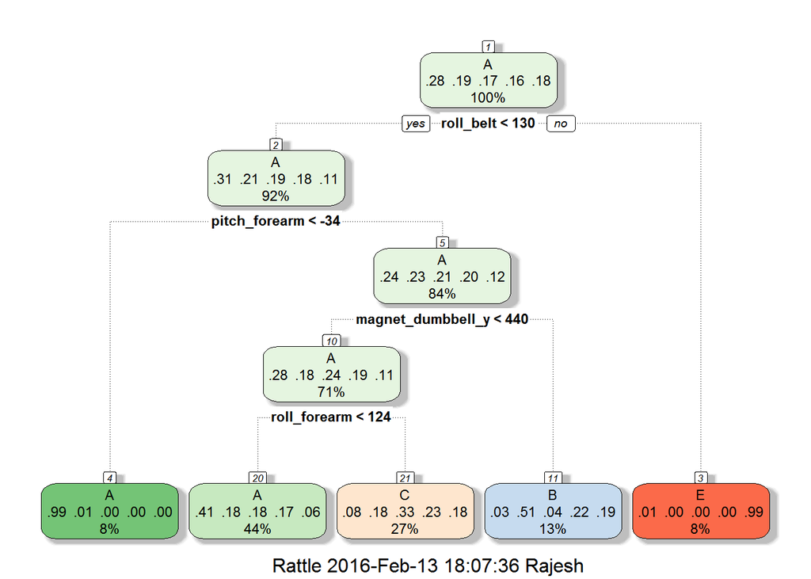

```r
mod_fit_tree <- train(form = classe~., data = train_data[, -1], method = "rpart")
fancyRpartPlot(mod_fit_tree$finalModel)
```

That’s not so good. This model didn’t predict any of the Ds.

# A random forest model

So I tried a random forest.

```r
mod_fit_rf <- train(form = classe~., data = train_data[, -1], method = "rf")
mod_fit_rf$finalModel
```

```
##
## Call:
##  randomForest(x = x, y = y, mtry = param$mtry)
##                Type of random forest: classification
##                      Number of trees: 500
## No. of variables tried at each split: 28
##
##         OOB estimate of  error rate: 0.06%
## Confusion matrix:
##      A    B    C    D    E  class.error
## A 5580    0    0    0    0 0.0000000000
## B    1 3795    1    0    0 0.0005267316
## C    0    5 3417    0    0 0.0014611338
## D    0    0    3 3212    1 0.0012437811
## E    0    0    0    0 3607 0.0000000000
```

```r
mod_fit_rf
```

```
## Random Forest
##
## 19622 samples
##    55 predictor
##     5 classes: 'A', 'B', 'C', 'D', 'E'
##
## No pre-processing
## Resampling: Bootstrapped (25 reps)
## Summary of sample sizes: 19622, 19622, 19622, 19622, 19622, 19622, ...
## Resampling results across tuning parameters:
##
##   mtry  Accuracy   Kappa      Accuracy SD   Kappa SD
##    2    0.9968150  0.9959712  0.0009539171  0.0012050393
##   28    0.9990008  0.9987360  0.0004907598  0.0006210568
##   55    0.9970029  0.9962085  0.0012979720  0.0016426849
##
## Accuracy was used to select the optimal model using  the largest value.
## The final value used for the model was mtry = 28.
```

Wow - that took a **long** time, good thing I set cache = TRUE. This looks pretty good, but do the variables used make sense?

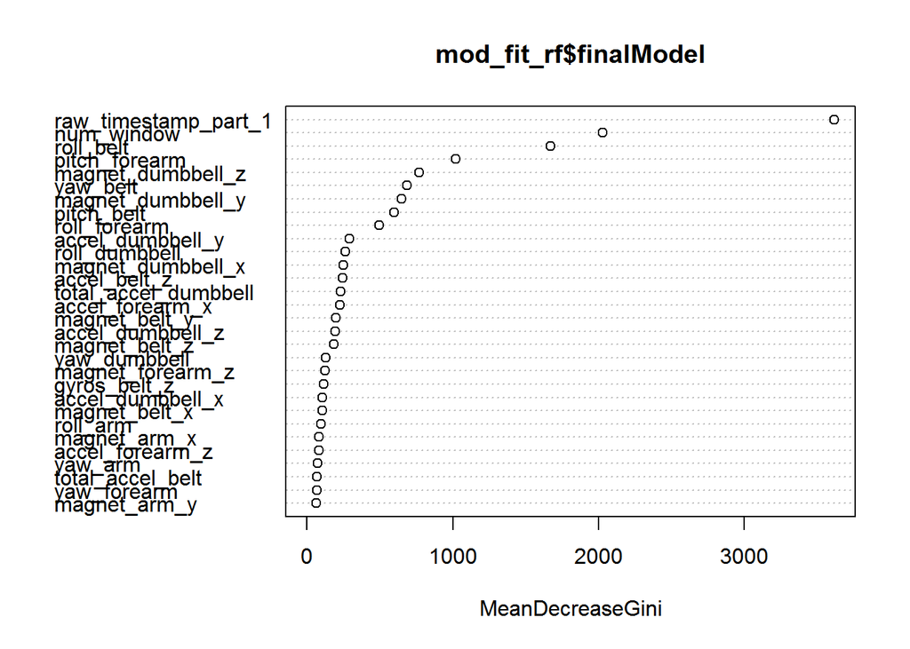

```r
varImpPlot(mod_fit_rf$finalModel)
```

# Cross validation,

I could have used cross-validation in selecting the model but it was pretty clear that the classification tree was not going to perform well.

# out of sample error rate

```r
trees <- mod_fit_rf$finalModel$ntree
oos_error <- paste(round(mod_fit_rf$finalModel$err.rate[trees ,"OOB"] * 100, 2), "percent")
print(oos_error)
```

```
## [1] "0.06 percent"
```

# Prediction

Now lets predit the class for the 20 subjects in the **test** dataset.

```r
preds_rf <- predict(mod_fit_rf, test_data)
table(preds_rf)
```

```
## preds_rf
## A B C D E
## 7 8 1 1 3
```

```r
data.frame(numer = 1:20, preds_rf)
```

```
##    numer preds_rf
## 1      1        B
## 2      2        A
## 3      3        B
## 4      4        A
## 5      5        A
## 6      6        E
## 7      7        D
## 8      8        B
## 9      9        A
## 10    10        A
## 11    11        B
## 12    12        C
## 13    13        B
## 14    14        A
## 15    15        E
## 16    16        E
## 17    17        A
## 18    18        B
## 19    19        B
## 20    20        B
```

I just submitted these for my quiz and got a 20/20. **YEAH!!!**